# Experimental Economics: Data Workflow

Lecture 5a: Sequential Experiments

Author

Matteo Ploner

Published

April 27, 2023

## 0.1 Sequential an simultaneous games

- **Sequential games**
  - Choices of one player are conditional upon choices of another player
    - Example: (mini) **Trust game**
- We will implement both
  - a *play* method version of the game
    - Only the nodes of the game actually reached are played
  - a *strategy* method version of the game
    - All nodes of the game are played, but the payoff is only assigned to the node reached

# 1 A (mini) Trust Game (TG)

## 1.1 Setting

- Players are matched in couples
  - A player is the first mover (Subject A)
  - A player is the second mover (Subject B)
- Subject A can choose between *enter* the game (Option 2) or *exit* the game (Option 1)
  - If enter → Subject B can choose between reward (Option 4) or exploit (Option 3)
  - If exit → Subject B has no choice to marker
- Payoffs are defined by the combination of choices by Subject A and B
  - (Option 1,.): 10, 0
  - (Option 2, Option 3): 0, 40
  - (Option 2, Option 4): 22, 18

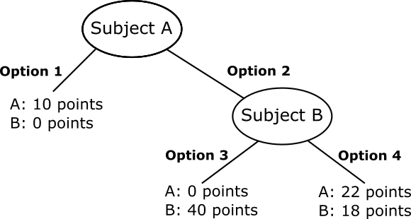

# 2 oTree code: **init.py**

## 2.1 Constants (models)

```python
class C(BaseConstants):
    NAME_IN_URL = 'trust_game_corso'
    PLAYERS_PER_GROUP = 2
    NUM_ROUNDS = 1
    P_1=[10,0] #payoffs exit
    P_2_3=[0,40] # payoffs entry, exploitation
    P_2_4 = [22, 18]  # payoffs entry, reciprocity
```

- Match participants in groups of 2
- Define here the payoffs as lists

## 2.2 Subsession (models)

```python
class Subsession(BaseSubsession):
pass

# Assign roles to players
def creating_session(player: Player):
    for g in player.get_groups():
        for p in g.get_players():
            if p.id_in_group == 1:
                first = True
            else:
                first = False
            p.first_mover = first
```

- Assign roles randomly using the ID in group
  - ID=1 is first mover
  - ID=2 is second mover

## 2.3 Group (models)

```python
class Group(BaseGroup):
    choice_1 = models.CharField(choices=[['Option 1','Option 1'], ['Option 2', 'Option 2']], widget=widgets.RadioSelectHorizontal, label="")
    choice_2 = models.CharField(choices=[['Option 3','Option 3'], ['Option 4', 'Option 4']], widget=widgets.RadioSelectHorizontal, label="")

# Compute payoffs
def set_payoffs(group: Group):
    p1 = group.get_player_by_id(1)
    p2 = group.get_player_by_id(2)
    if group.choice_1 == 'Option 1':
        p1.payoff = C.P_1[0]
        p2.payoff = C.P_1[1]
    else:
        if group.field_maybe_none('choice_2') == 'Option 3':
            p1.payoff = C.P_2_3[0]
            p2.payoff = C.P_2_3[1]
        else:
            p1.payoff = C.P_2_4[0]
            p2.payoff = C.P_2_4[1]
```

- Choices are defined for class Group
- Payoffs are defined at the group level
  - Outcome is conditional upon choice of Subject A and Subject B

## 2.4 Player (models)

```python
class Player(BasePlayer):
    first_mover = models.BooleanField()
    treatment=  models.CharField()
```

- Role of the player

page_sequence = [Instructions, Choice_1, SendWaitPage, Choice_2, ResultsWaitPage, Results]

## 2.5 Instructions (pages)

```python
class Instructions(Page):
    @staticmethod
    def vars_for_template(player: Player):
        if player.session.config['treatment'] == "play":
            return {
                'play': True
            }
        else:
            return {
                'play': False
            }
```

- To condition the instructions on the treatment
- In settings.py

```python
   dict(
        name='TG',
        app_sequence=['TG_2'],
        num_demo_participants=2,
        treatment = "play"# play= sequential; method= strategy method
    )
```

- If *play* → instructions are different
  - **Subject B will choose after knowing the choice of Player A.**
- If *method* → instructions are different
  - **Subject B will choose before knowing the choice of Player A.**

## 2.6 Choice_1

```python
class Choice_1(Page):
    form_model = 'group'
    form_fields = ['choice_1']

    @staticmethod
    def is_displayed(player: Player):
        return player.first_mover == 1
```

- Collect the choice of Subject A
  - Notice that the field “belongs” to Group
- The page is displayed only if the Subject is a first mover
  - As defined in Subsession

## 2.7 SendWaitPage

```python
class SendWaitPage(WaitPage):
    def is_displayed(player: Player):
        return player.session.config['treatment'] == "play"
```

- A waiting page so that Subject B waits that Subject A makes her choice -Displayed only for the *play* treatment

## 2.8 Choice_2

```python
class Choice_2(Page):
    form_model = 'group'
    form_fields = ['choice_2']

    @staticmethod
    def vars_for_template(player: Player):
        if player.session.config['treatment'] == "play":
            return {
                'display': True,
                'choice_other': player.group.choice_1
            }
        else:
            return {
                'display': False
            }


    @staticmethod
    def is_displayed(player: Player):
        if player.session.config['treatment'] == "play":
            return player.first_mover == False and player.group.choice_1 == 'Option 2'
        else:
            return player.first_mover == False
```

- Collect the choice of Subject B
- `vars_for_template` to display the choice of A
- *play* treatment
  - The page is displayed only if two conditions are simultaneously met
    - Player is not a first mover
    - First mover chose Option 2
  - Otherwise, Subject B has no choice to make
- *method* treatment
  - The page is displayed only if the player is not a first mover

## 2.9 ResultsWaitPage

```python
class ResultsWaitPage(WaitPage):
    after_all_players_arrive = 'set_payoffs'
```

- A waiting page so that Subject A waits that Subject B makes her choice
- After all make their choices we can compute payoffs
  - set_payoffs() at the Group level

## 2.10 Results

```python
class Results(Page):

    @staticmethod
    def vars_for_template(player: Player):
        return {
            'first_mover': player.first_mover,
            'choice_1': player.group.choice_1,
            'choice_2': player.group.field_maybe_none('choice_2'),
            'payoff': player.payoff
        }
```

- `field_maybe_none()` is needed because ‘choice_2’ may possibly be None
  - When second mover in *play* has no choice to make
- Variables needed to give feedback
  - `payoff` captures the earnings in the game

# 3 Templates

## 3.1 Instructions

```html
{{ extends "global/Page.html" }}
{{ load otree static }}

{{ block title }}
    Instructions
{{ endblock }}

{{ block content }}


<p>Consider the following situation:</p>

<p>Two participants to this study are randomly and anonymously paired. One participant is labelled <i>Subject A</i> and the other <i>Subject B.</i>
</p>

<p>Subject A must decide among two alternatives, called <i>Option 1</i> and <i>Option 2.</i></p>
<br>
<center><img src="{{ static "TG/en.png" }}" width=300 /></center>
<br>
<ul>
    <li>
        <b>Option 1:</b> Subject A keeps the 10 Points and nothing is passed to Subject B. The game ends without Subject B taking any decision and earnings will be 10 Points for Subject A and 0 Points for Subject B, respectively.
    </li>
    <li>
        <b>Option 2:</b> Subject A passes 10 Points to Subject B. The 10 Points will be multiplied by a factor of 4, thus Subject B will receive 40 Points. In this case Subject B must decide among <i>Option 3</i> and <i>Option 4</i>:
    </li>
    <li>
        <b>Option 3:</b> Subject B keeps the 40 Points and nothing is passed back to Subject A. Earnings will be 0 Points for Subject A and 40 Points for Subject B, respectively.
    </li>
    <li>
        <b>Option 4:</b> Subject B keeps the 18 Points and passes back 22 Points to Subject A. Earnings will be 22 Points for Subject A and 18 Points for Subject B, respectively.
    </li>
</ul>

One of the participants in each couple is randomly assigned to be Subject A and the other to be Subject B.<br>


{{ if play == True}}

Subject B will choose after knowing the choice of Player A.

{{ else}}

Subject B will choose before knowing the choice of Player A.

{{ endif }}

<div class="container" style="font-size:12pt">
    <div class="row">
        &nbsp;
    </div>
    <div class="row" style="padding-left:135px;">
        <div class="col-md-10">
        </div>
        <div class="col-md-2">
            <button name="btn_submit" value="True" class="btn btn-primary btn-large">
                <span style="font-size:18pt">Start</span>
            </button>
        </div>
    </div>
</div>

{{ endblock }}
```

- A figure is included in the template
  - Imported from static folder
- The last sentence is conditional upon the treatment
  - `play` is a variable passed to the template
  - `play` is defined in the view

## 3.2 Choice_1

```html
{{ extends "global/Page.html" }}
{{ load otree static }}

{{ block title }}
    You are Subject A
{{ endblock }}


{{ block content }}

<center><img src="{{ static "TG/en.png" }}" /></center>

 {{ formfield group.choice_1 label="Please choose between Option 1 and Option 2:" }}

<div class="container" style="font-size:12pt">
    <div class="row">
        &nbsp;
    </div>
    <div class="row" style="padding-left:135px;">
        <div class="col-md-10">
        </div>
        <div class="col-md-2">
            <button name="btn_submit" value="True" class="btn btn-primary btn-large">
                <span style="font-size:18pt">Confirm</span>
            </button>
        </div>
    </div>
</div>

{{ endblock }}
```

- The template is very simple
  - A figure is included
  - A form field is included
    - `formfield` is a template tag
    - `group.choice_1` is the field to be displayed
  - A button to confirm the choice

## 3.3 Choice_2

```html
{{ extends "global/Page.html" }}
{{ load otree static }}

{{ block title }}
    You are Subject B
{{ endblock }}

{{ block content }}

{{ if display == True}}

Subject A chose {{choice_other}}.

{{else}}

{{endif}}

<br>

<center><img src="{{ static "TG/en.png" }}" /></center>

 {{ formfield group.choice_2 label="Please choose between Option 3 and Option 4:" }}

<div class="container" style="font-size:12pt">
    <div class="row">
        &nbsp;
    </div>
    <div class="row" style="padding-left:135px;">
        <div class="col-md-10">
        </div>
        <div class="col-md-2">
            <button name="btn_submit" value="True" class="btn btn-primary btn-large">
                <span style="font-size:18pt">Confirm</span>
            </button>
        </div>
    </div>
</div>

{{ endblock }}
```

- The template is very similar to the previous one
  - A conditional sentence is included
    - `display` is a variable passed to the template
  - A form field is included
    - `formfield` is a template tag
    - `group.choice_2` is the field to be displayed
  - A button to confirm the choice

## 3.4 Results

```html
{{ extends "global/Page.html" }}
{{ load otree static }}

{{ block title }}
    Results
{{ endblock }}

{{ block content }}
<center><img src="{{ static "TG/en.png" }}" /></center>
{{ if first_mover == True }}
    You were a Subject A. <br>You chose {{choice_1 }}. <br>
     The other chose {{ choice_2 }}.
{{ else }}
    You were a Subject B. <br>
        You chose {{ choice_2 }}.<br>
        The other chose {{ choice_1 }}.
  {{ endif }}



<br>
Thus, you earn {{ payoff }}.
<br>

<div class="container" style="font-size:12pt">
    <div class="row">
        &nbsp;
    </div>
    <div class="row" style="padding-left:135px;">
        <div class="col-md-10">
        </div>
        <div class="col-md-2">
            <button name="btn_submit" value="True" class="btn btn-primary btn-large">
                <span style="font-size:18pt">Finish</span>
            </button>
        </div>
    </div>
</div>
{{ endblock }}
```

- A conditional sentence is included
  - `first_mover` is a variable passed to the template
    - To differentiate the display of the results
- A button to confirm the choice

# 4 Appendix

## 4.1 OTree code

- Trust Game

Download TG.zip